# An Overview of Oregon’s State Funding Allocation

Author

Havisha Khurana

Published

Monday, March 17, 2025

In Oregon, state and local revenues are pooled together and redistributed to school districts based on a funding formula. Approximately 60% of the total education budget comes from the state’s share, making it a critical revenue source for most districts. The **State School Fund (SSF)** allocates lump-sum funding to districts based on the number of resident students, adjusted for differential needs as specified by the Oregon Revised Statutes (ORS 327.008). Students with disabilities are double-weighted in the funding formula, with districts guaranteed double-weighted funding for up to 11% of their student population. Other student groups, such as students classified as English Language Learners or those qualifying for Free-or-reduced price lunch are also proportionately weighted in the formula. While state allocations are tied to student demographics, districts have the flexibility to use these revenues as they see fit.

Another state fiscal policy to support students with disabilities is the **High-Cost Disability Fund**, which reimburses districts for expenses exceeding $30,000 per special education student (the cap was at $25,000 from 2003-2005). Each year, a portion of the SSF, amounting to less than 5% of the total appropriation, is designated for this fund. If statewide claims exceed the available funds, reimbursements are prorated across districts.

In this analysis, I will describe descriptive trends in district enrollment, districts’ state-funding allocation, district revenue, and district expenditure related to students with disabilities whose services cost more than a given threshold and are paid by the grant called *High-Cost Disability Fund*.

## District ADM Data

*District-level allocations from the State School Fund (SSF), disaggregated by student type, covering the years 2011–2024.*

### Trends in Enrollment

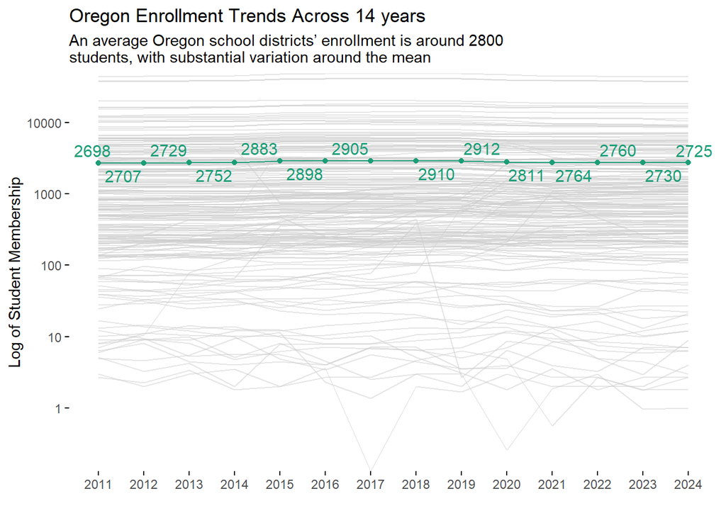

An average Oregon school districts’ enrollment is around 2800 students- which remains pretty stable across the years. However, there is substantial variation in enrollment between districts.

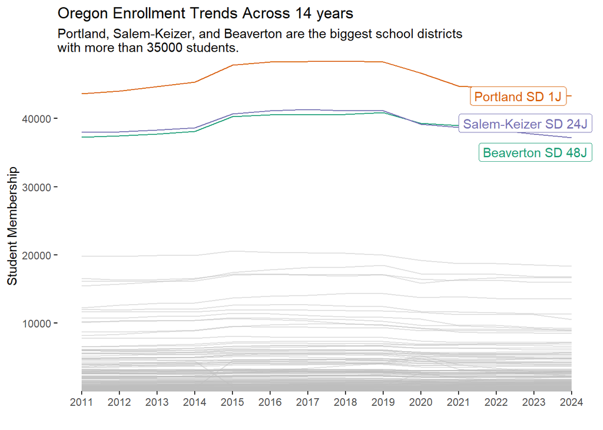

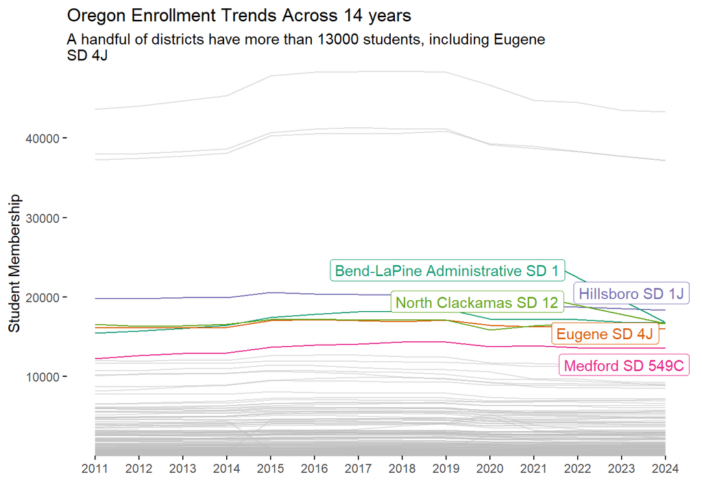

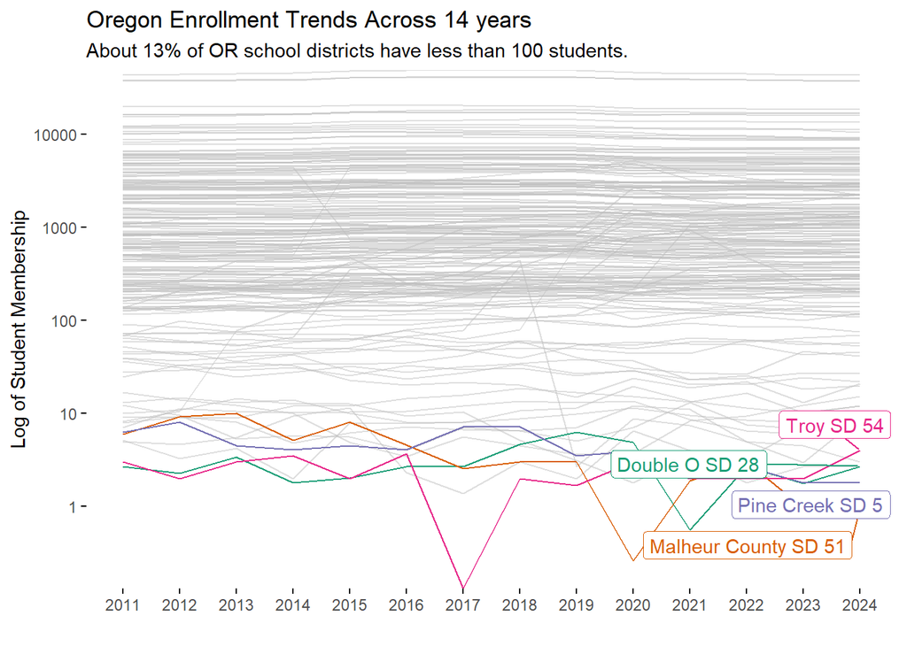

### State Trends for Subgroup Enrollment

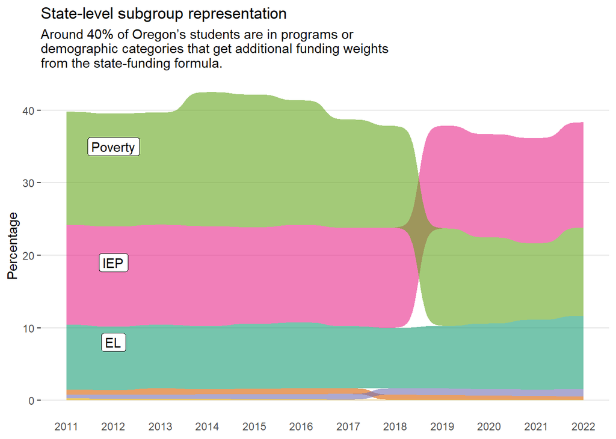

The three biggest groups are students under poverty, students served in special education and in English language programs.

In 2011, about 16% of the all students were under poverty, 14% of all students were in special education programs and 9% of students were in the ESL programs. In 2024, students served in special education was the biggest group at 15% followed by students under poverty and students in ELP at around 12%. About 1% of the students are in other programs.

### District Trends for Subgroup Enrollment

Next, we look at the trends percentage of subgroup representation across districts over time.

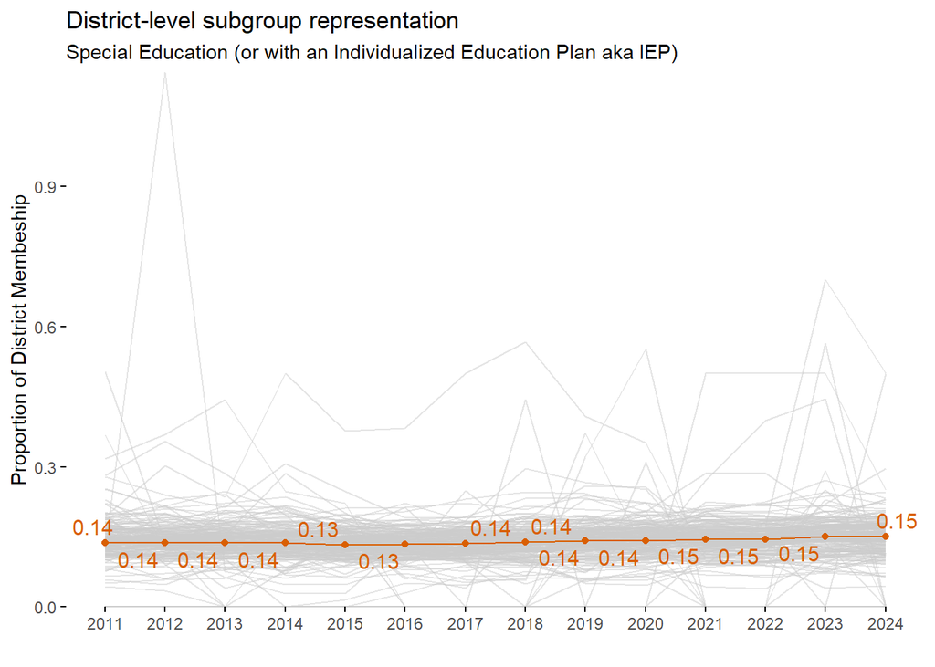

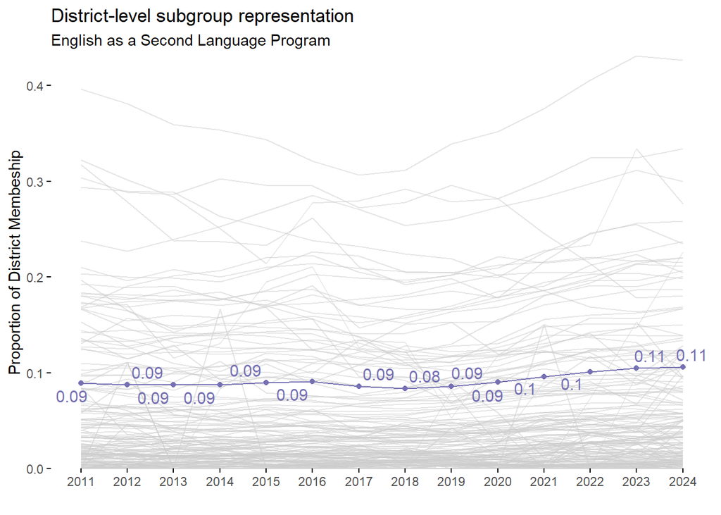

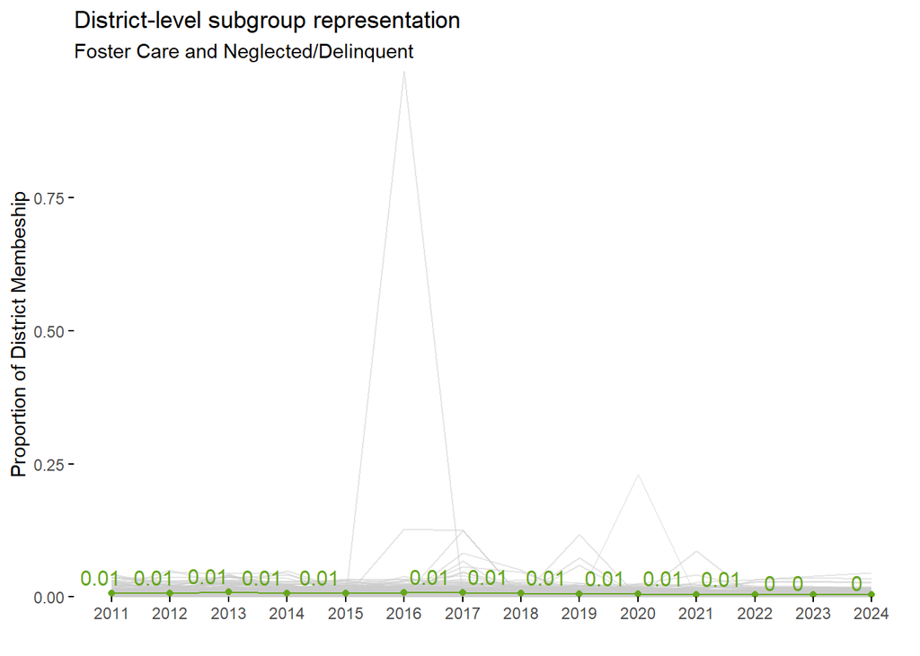

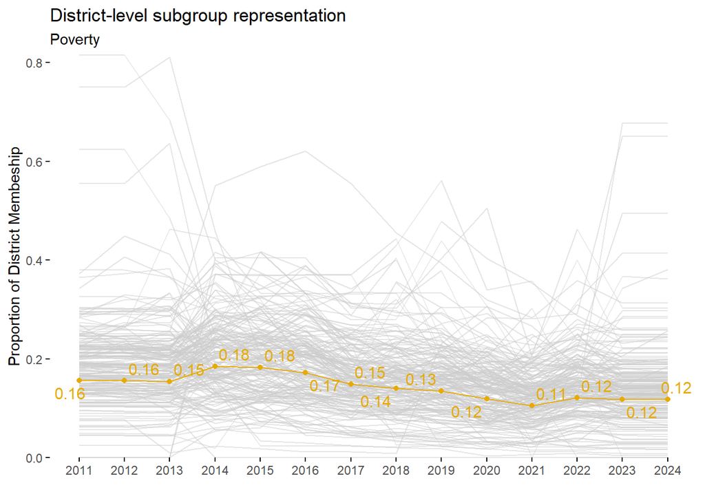

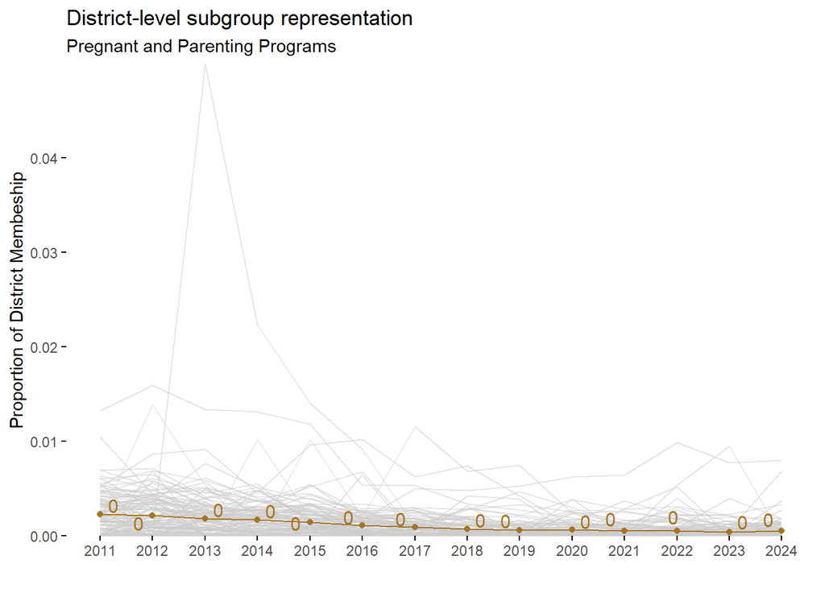

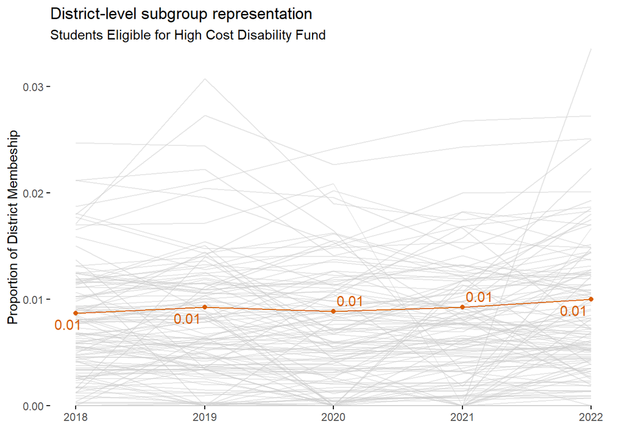

Students in special education (IEP or students with an Individualized Education Plans) and English language programs have been steadily growing over the years, and those classified in poverty are steadily decreasing, but there is plenty of between-district variation.

Between 0 to 3% of students were classified as HCD (eligible for High Cost Disability Fund) between districts between 2018 to 2022.

### Relationship between Districts Total Enrollment and Subgroup Enrollment

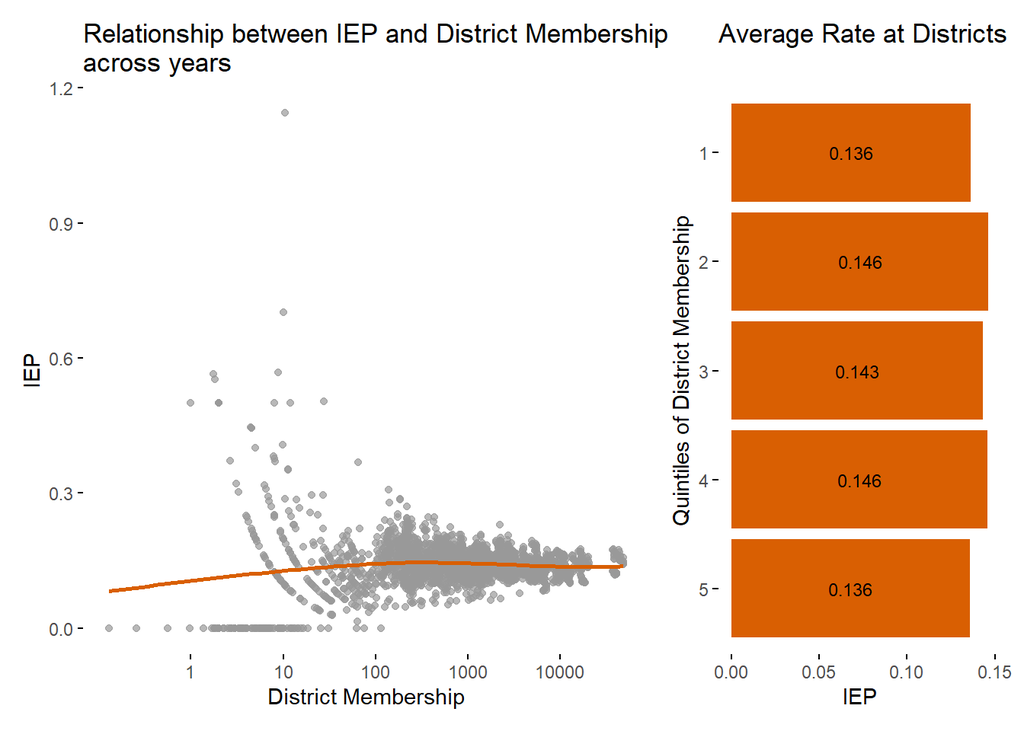

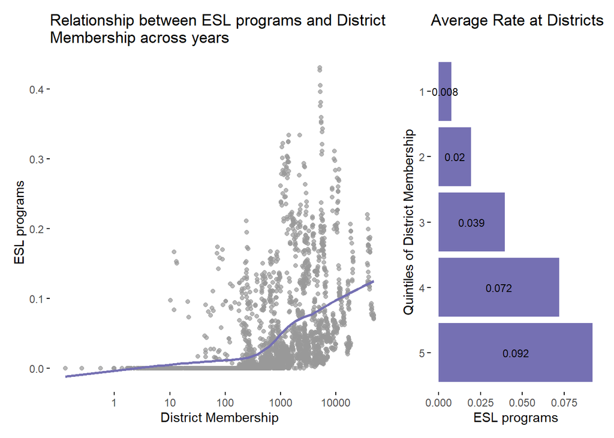

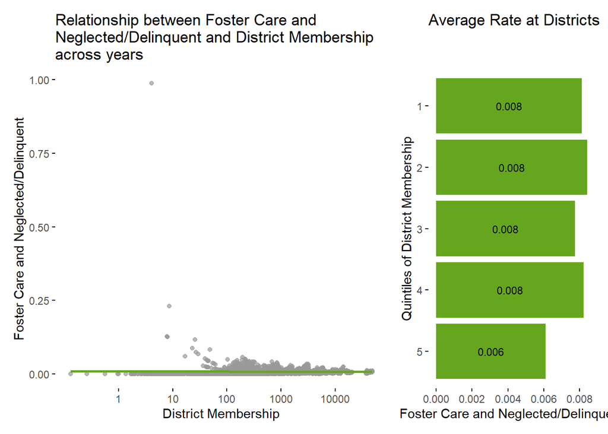

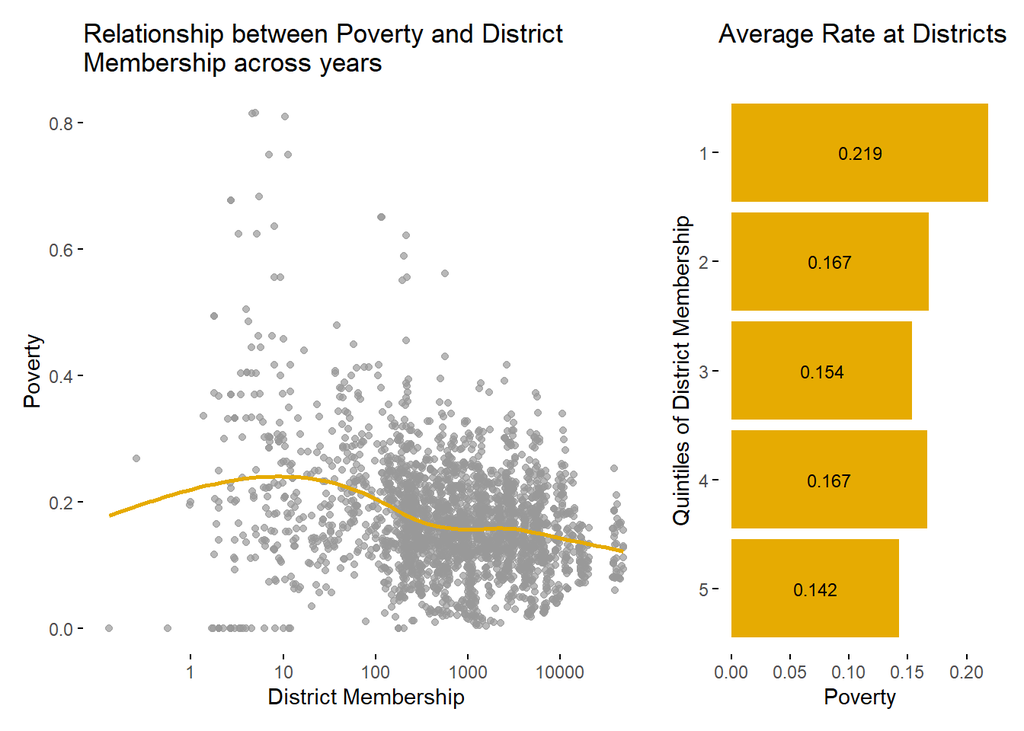

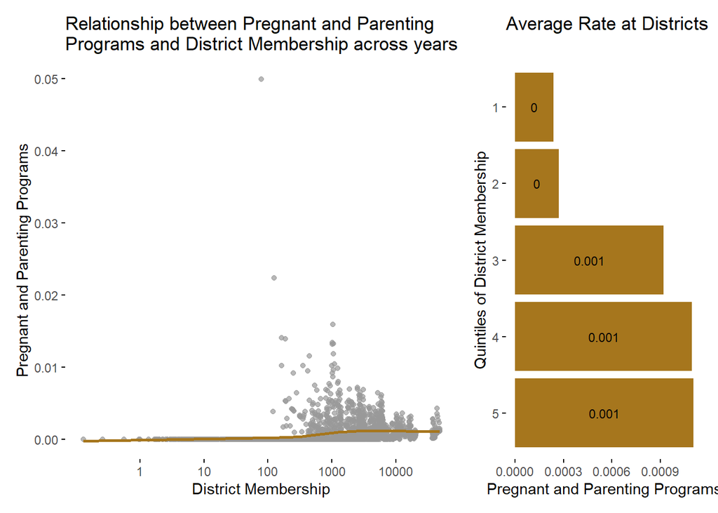

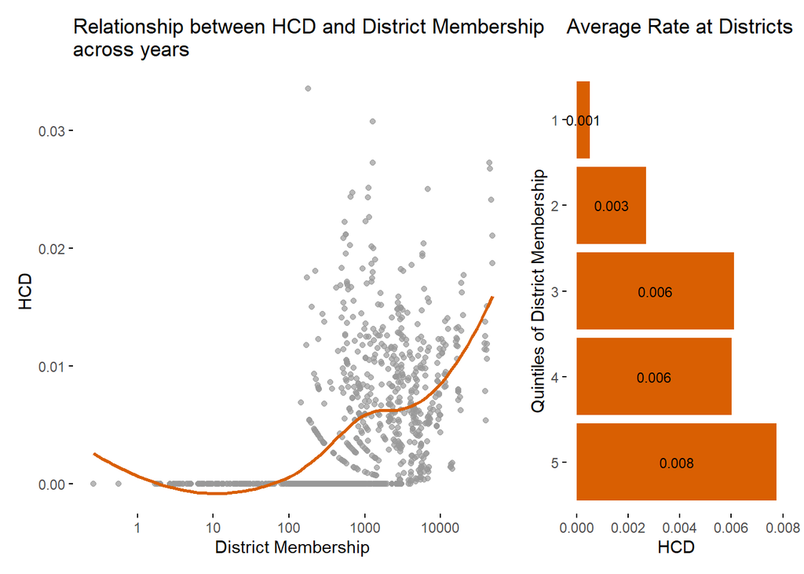

## District Funds Allocation Data

I define **allocation ratio** as the ratio of weighted average daily membership to the real average daily membership. Since students with some characteristics are weighted more than 1 per the state formula, a district gets resources as if there were more students in the school. So, an allocation ratio of 2 means that districts get 2 student equivalent for every 1 real student in their district.

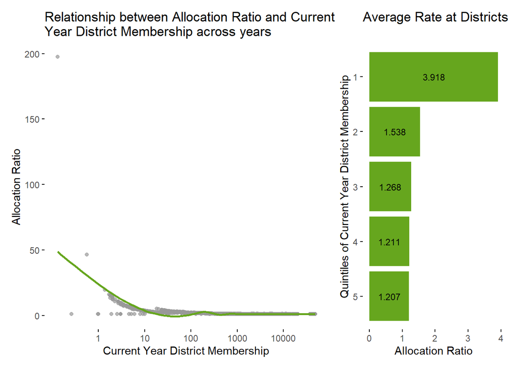

## Revenue Data

### State Trends in Per-pupil revenue

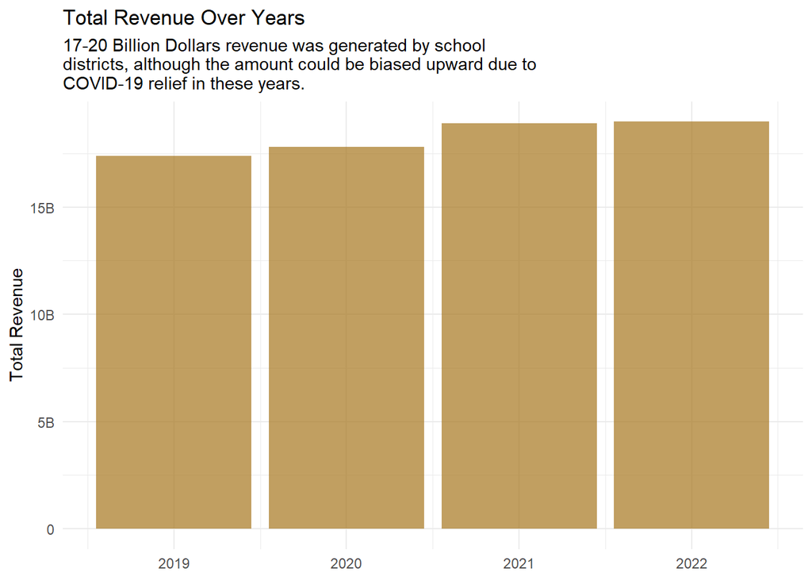

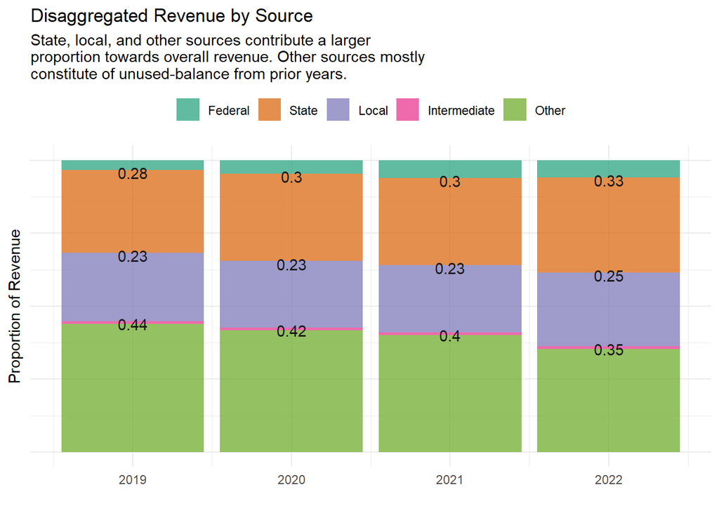

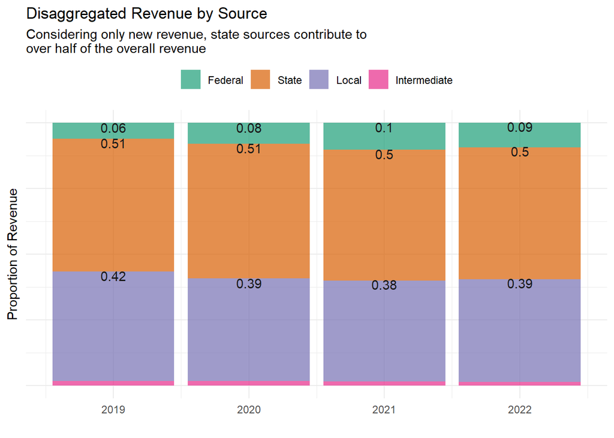

Almost all of state revenue is allocated using the SSF. Local revenue could be tax levies etc. The biggest contributor to Other resources are districts’ account balance from previous years – thus, districts saved substantial money from past years. The decrease in other sourcecs over the 4 years could be related to using emergency resources in response to COVID-19 related disruptions.

If we remove the other sources and only consider the new money districts get, about 50% comes from state resources and 40 percent come from local resources. Between 6 to 10% percent come from federal sources.

### Trends in Per-pupil revenue by Districts based on sources

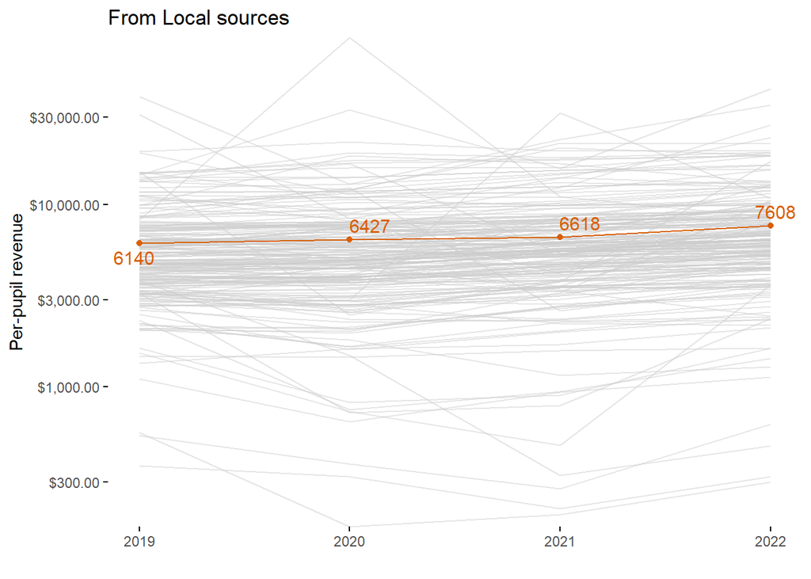

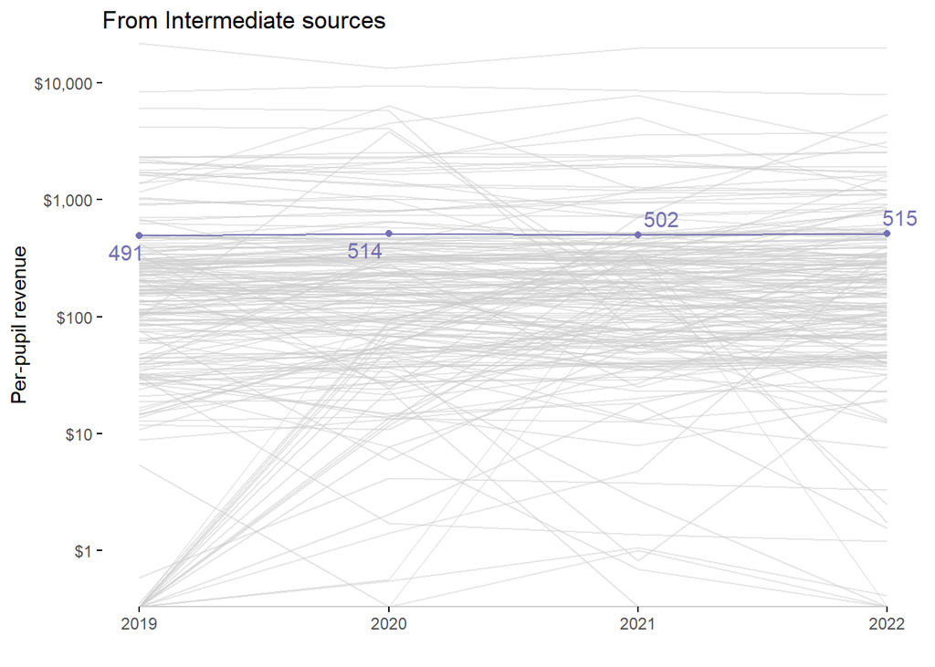

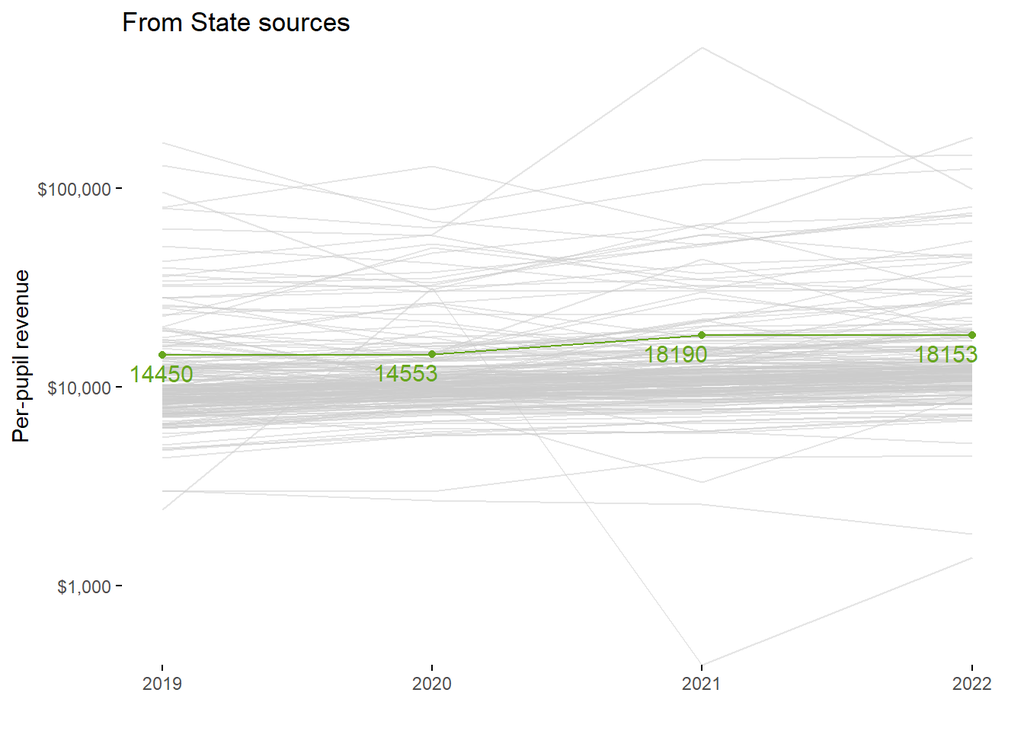

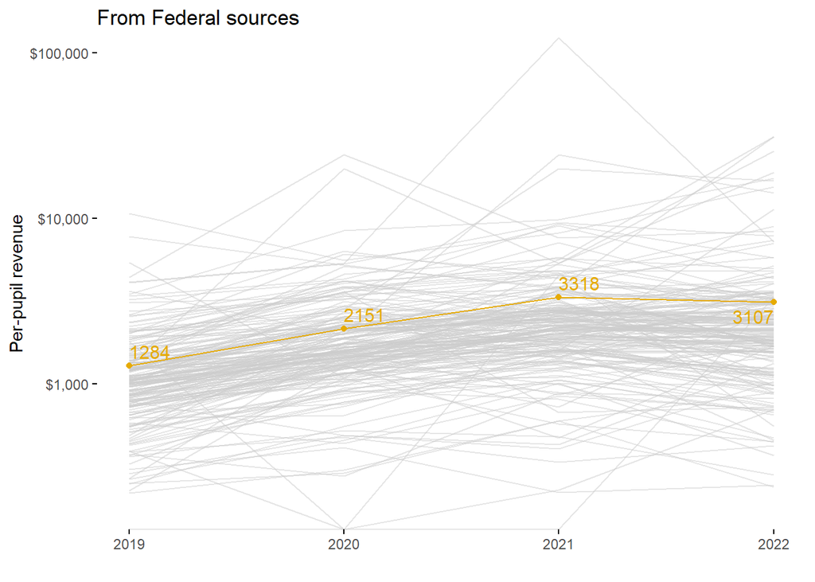

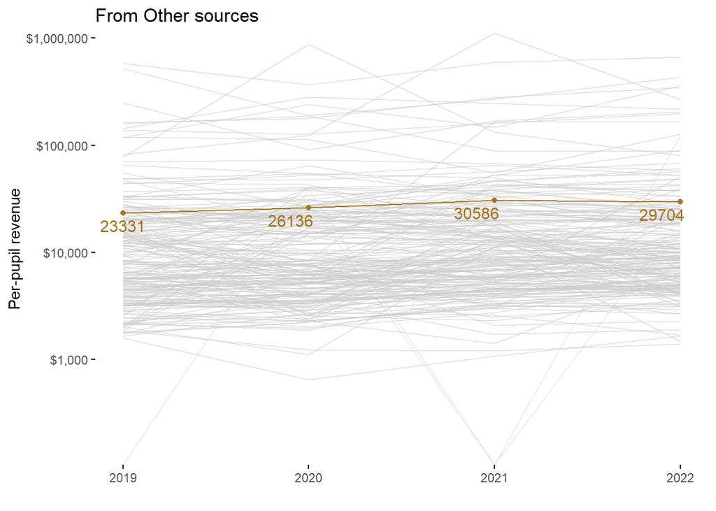

The average per-pupul revenue from all sources, except intermediate, went up from 2019 to 2022. Although the most dramatic increase in revenue was from federal sources, which went up about three times between 2019 to 2021. Revenue from local and intermediate sources remained more consistent over time.

### Trends in Revenue by District Enrollment

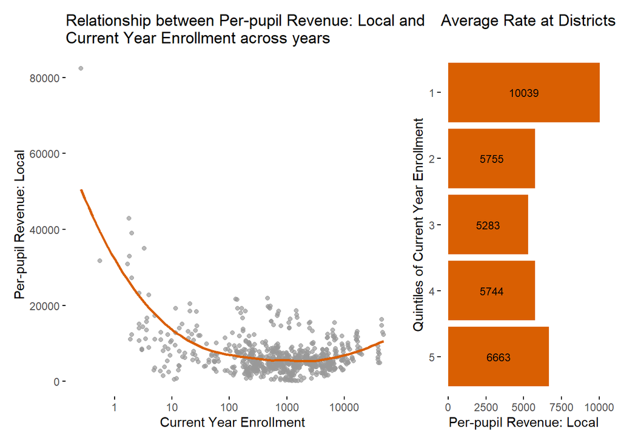

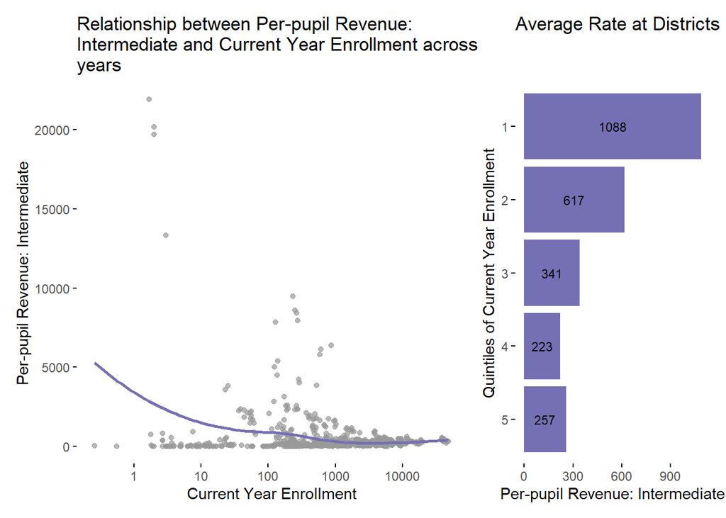

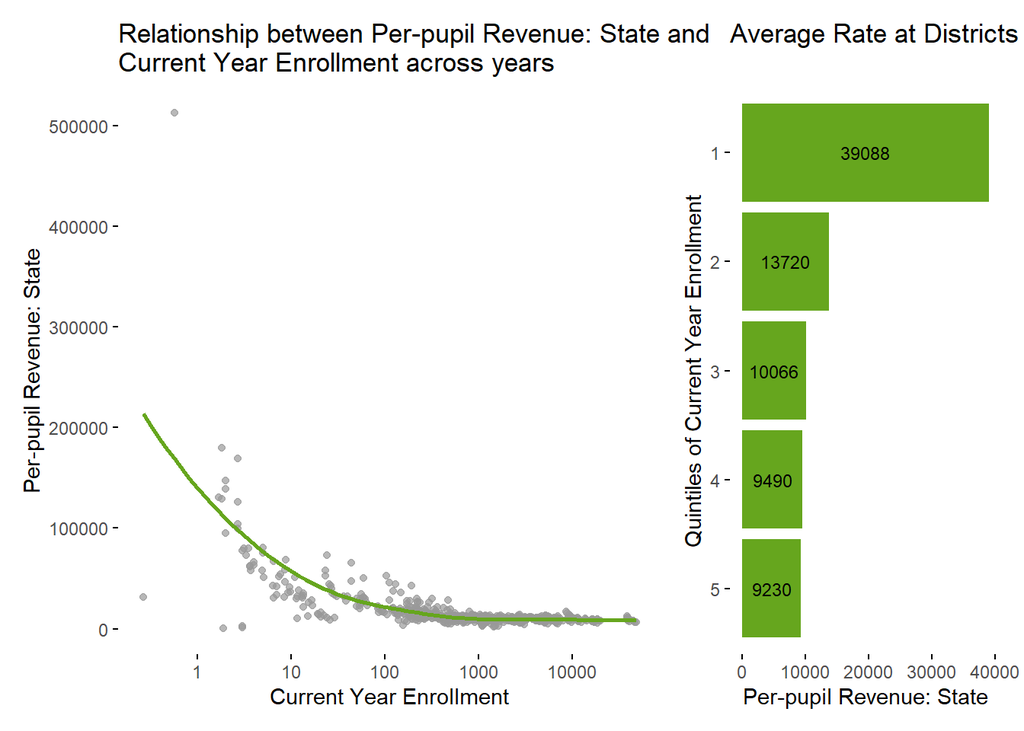

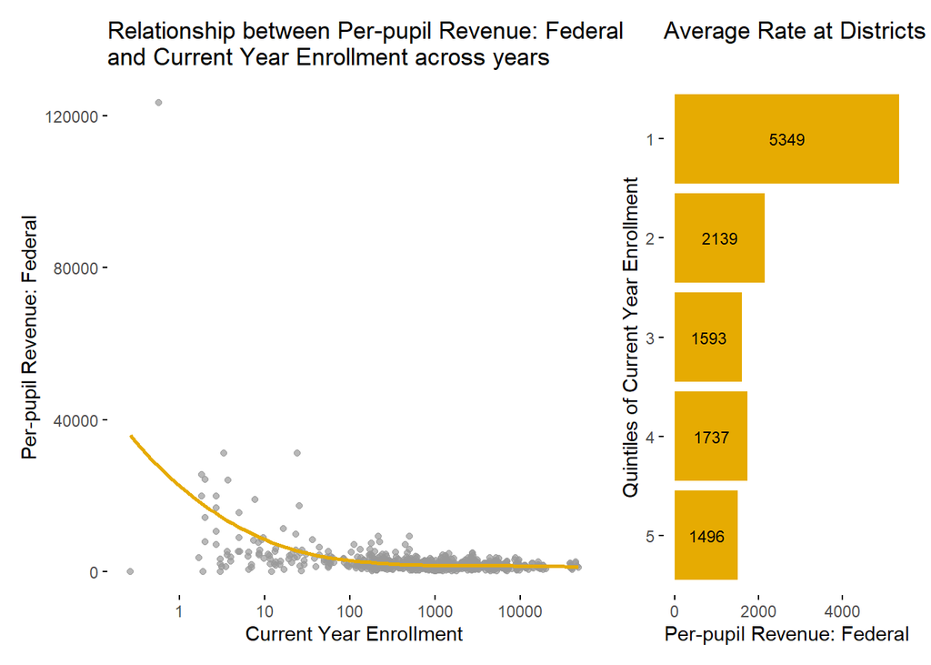

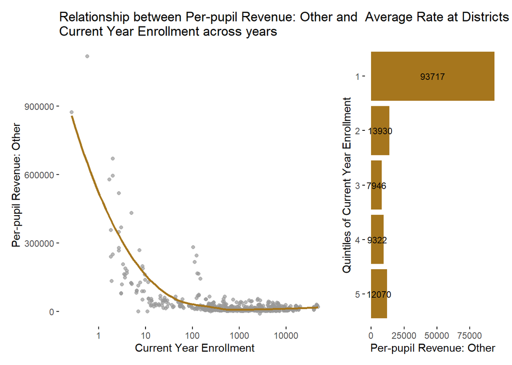

Districts with smaller enrollment have a much higher per-pupil revenue from all sources compared to big districts. The most dramatic difference is in per-pupil revenue by other sources.